# Risk Factor Analysis

## Outcome Variable

**Outcome Variable:** wast_rec90d

## Predictor Variables

**Intervention Variable:** predfeed36

**Adjustment Set:**

unadjusted

## Stratifying Variables

The analysis was stratified on these variable(s):

- agecat
- studyid
- country

## Data Summary

| agecat | studyid | country | predfeed36 | wast_rec90d | n_cell | n |
| --- | --- | --- | --- | --- | --- | --- |
| 0-24 months | EE | PAKISTAN | 1 | 0 | 1 | 4 |
| 0-24 months | EE | PAKISTAN | 1 | 1 | 0 | 4 |
| 0-24 months | EE | PAKISTAN | 0 | 0 | 0 | 4 |
| 0-24 months | EE | PAKISTAN | 0 | 1 | 3 | 4 |
| 0-24 months | GMS-Nepal | NEPAL | 1 | 0 | 190 | 559 |
| 0-24 months | GMS-Nepal | NEPAL | 1 | 1 | 257 | 559 |
| 0-24 months | GMS-Nepal | NEPAL | 0 | 0 | 52 | 559 |
| 0-24 months | GMS-Nepal | NEPAL | 0 | 1 | 60 | 559 |
| 0-24 months | JiVitA-3 | BANGLADESH | 1 | 0 | 1676 | 3743 |
| 0-24 months | JiVitA-3 | BANGLADESH | 1 | 1 | 1227 | 3743 |
| 0-24 months | JiVitA-3 | BANGLADESH | 0 | 0 | 495 | 3743 |
| 0-24 months | JiVitA-3 | BANGLADESH | 0 | 1 | 345 | 3743 |
| 0-24 months | JiVitA-4 | BANGLADESH | 1 | 0 | 949 | 1787 |
| 0-24 months | JiVitA-4 | BANGLADESH | 1 | 1 | 360 | 1787 |
| 0-24 months | JiVitA-4 | BANGLADESH | 0 | 0 | 344 | 1787 |
| 0-24 months | JiVitA-4 | BANGLADESH | 0 | 1 | 134 | 1787 |
| 0-24 months | LCNI-5 | MALAWI | 1 | 0 | 5 | 34 |
| 0-24 months | LCNI-5 | MALAWI | 1 | 1 | 2 | 34 |
| 0-24 months | LCNI-5 | MALAWI | 0 | 0 | 22 | 34 |
| 0-24 months | LCNI-5 | MALAWI | 0 | 1 | 5 | 34 |
| 0-24 months | MAL-ED | BANGLADESH | 1 | 0 | 13 | 121 |
| 0-24 months | MAL-ED | BANGLADESH | 1 | 1 | 30 | 121 |
| 0-24 months | MAL-ED | BANGLADESH | 0 | 0 | 30 | 121 |
| 0-24 months | MAL-ED | BANGLADESH | 0 | 1 | 48 | 121 |
| 0-24 months | MAL-ED | BRAZIL | 1 | 0 | 0 | 24 |
| 0-24 months | MAL-ED | BRAZIL | 1 | 1 | 1 | 24 |
| 0-24 months | MAL-ED | BRAZIL | 0 | 0 | 6 | 24 |
| 0-24 months | MAL-ED | BRAZIL | 0 | 1 | 17 | 24 |
| 0-24 months | MAL-ED | INDIA | 1 | 0 | 2 | 178 |
| 0-24 months | MAL-ED | INDIA | 1 | 1 | 6 | 178 |

[output cut: 126 more lines]

The following strata were considered:

- agecat: 0-24 months, studyid: EE, country: PAKISTAN
- agecat: 0-24 months, studyid: GMS-Nepal, country: NEPAL
- agecat: 0-24 months, studyid: JiVitA-3, country: BANGLADESH
- agecat: 0-24 months, studyid: JiVitA-4, country: BANGLADESH
- agecat: 0-24 months, studyid: LCNI-5, country: MALAWI
- agecat: 0-24 months, studyid: MAL-ED, country: BANGLADESH
- agecat: 0-24 months, studyid: MAL-ED, country: BRAZIL
- agecat: 0-24 months, studyid: MAL-ED, country: INDIA
- agecat: 0-24 months, studyid: MAL-ED, country: NEPAL
- agecat: 0-24 months, studyid: MAL-ED, country: PERU
- agecat: 0-24 months, studyid: MAL-ED, country: SOUTH AFRICA
- agecat: 0-24 months, studyid: MAL-ED, country: TANZANIA, UNITED REPUBLIC OF
- agecat: 0-24 months, studyid: SAS-FoodSuppl, country: INDIA
- agecat: 0-6 months, studyid: EE, country: PAKISTAN
- agecat: 0-6 months, studyid: GMS-Nepal, country: NEPAL
- agecat: 0-6 months, studyid: JiVitA-3, country: BANGLADESH
- agecat: 0-6 months, studyid: JiVitA-4, country: BANGLADESH
- agecat: 0-6 months, studyid: LCNI-5, country: MALAWI
- agecat: 0-6 months, studyid: MAL-ED, country: BANGLADESH
- agecat: 0-6 months, studyid: MAL-ED, country: BRAZIL
- agecat: 0-6 months, studyid: MAL-ED, country: INDIA
- agecat: 0-6 months, studyid: MAL-ED, country: NEPAL
- agecat: 0-6 months, studyid: MAL-ED, country: PERU
- agecat: 0-6 months, studyid: MAL-ED, country: SOUTH AFRICA
- agecat: 0-6 months, studyid: MAL-ED, country: TANZANIA, UNITED REPUBLIC OF
- agecat: 0-6 months, studyid: SAS-FoodSuppl, country: INDIA
- agecat: 6-24 months, studyid: EE, country: PAKISTAN
- agecat: 6-24 months, studyid: GMS-Nepal, country: NEPAL
- agecat: 6-24 months, studyid: JiVitA-3, country: BANGLADESH
- agecat: 6-24 months, studyid: JiVitA-4, country: BANGLADESH
- agecat: 6-24 months, studyid: LCNI-5, country: MALAWI
- agecat: 6-24 months, studyid: MAL-ED, country: BANGLADESH
- agecat: 6-24 months, studyid: MAL-ED, country: BRAZIL
- agecat: 6-24 months, studyid: MAL-ED, country: INDIA
- agecat: 6-24 months, studyid: MAL-ED, country: NEPAL
- agecat: 6-24 months, studyid: MAL-ED, country: PERU
- agecat: 6-24 months, studyid: MAL-ED, country: SOUTH AFRICA
- agecat: 6-24 months, studyid: MAL-ED, country: TANZANIA, UNITED REPUBLIC OF
- agecat: 6-24 months, studyid: SAS-FoodSuppl, country: INDIA

### Dropped Strata

Some strata were dropped due to rare outcomes:

- agecat: 0-24 months, studyid: EE, country: PAKISTAN
- agecat: 0-24 months, studyid: LCNI-5, country: MALAWI
- agecat: 0-24 months, studyid: MAL-ED, country: BRAZIL
- agecat: 0-24 months, studyid: MAL-ED, country: INDIA
- agecat: 0-24 months, studyid: MAL-ED, country: NEPAL
- agecat: 0-24 months, studyid: MAL-ED, country: PERU
- agecat: 0-24 months, studyid: MAL-ED, country: SOUTH AFRICA
- agecat: 0-24 months, studyid: MAL-ED, country: TANZANIA, UNITED REPUBLIC OF
- agecat: 0-24 months, studyid: SAS-FoodSuppl, country: INDIA
- agecat: 0-6 months, studyid: EE, country: PAKISTAN
- agecat: 0-6 months, studyid: LCNI-5, country: MALAWI
- agecat: 0-6 months, studyid: MAL-ED, country: BANGLADESH
- agecat: 0-6 months, studyid: MAL-ED, country: BRAZIL
- agecat: 0-6 months, studyid: MAL-ED, country: INDIA
- agecat: 0-6 months, studyid: MAL-ED, country: NEPAL
- agecat: 0-6 months, studyid: MAL-ED, country: PERU
- agecat: 0-6 months, studyid: MAL-ED, country: SOUTH AFRICA
- agecat: 0-6 months, studyid: MAL-ED, country: TANZANIA, UNITED REPUBLIC OF
- agecat: 0-6 months, studyid: SAS-FoodSuppl, country: INDIA
- agecat: 6-24 months, studyid: EE, country: PAKISTAN
- agecat: 6-24 months, studyid: JiVitA-3, country: BANGLADESH
- agecat: 6-24 months, studyid: LCNI-5, country: MALAWI
- agecat: 6-24 months, studyid: MAL-ED, country: BRAZIL
- agecat: 6-24 months, studyid: MAL-ED, country: INDIA
- agecat: 6-24 months, studyid: MAL-ED, country: NEPAL
- agecat: 6-24 months, studyid: MAL-ED, country: PERU
- agecat: 6-24 months, studyid: MAL-ED, country: SOUTH AFRICA
- agecat: 6-24 months, studyid: MAL-ED, country: TANZANIA, UNITED REPUBLIC OF
- agecat: 6-24 months, studyid: SAS-FoodSuppl, country: INDIA

## Methods Detail

We’re interested in the causal parameters $E[Y_a]$ for all values of $a \in \mathcal{A}$. These parameters represent the mean outcome if, possibly contrary to fact, we intervened to set all units to have $A=a$. Under the randomization and positivity assumptions, these are identified by the statistical parameters $\psi_a=E_W[E_{Y|A,W}(Y|A=a,W)]$. In addition, we’re interested in the mean of $Y$, $E[Y]$ under no intervention (the observed mean). We will estimate these parameters by using SuperLearner to fit the relevant likelihood factors – $E_{Y|A,W}(Y|A=a,W)$ and $p(A=a|W)$, and then updating our likelihood fit using a joint TMLE.

For unadjusted analyses ($W=\{\}$), initial likelihoods were estimated using Lrnr_glm to estimate the simple $E(Y|A)$ and Lrnr_mean to estimate $p(A)$. For adjusted analyses, a small library containing Lrnr_glmnet, Lrnr_xgboost, and Lrnr_mean was used.

Having estimated these parameters, we will then use the delta method to estimate relative risks and attributable risks relative to a prespecified baseline level of $A$.

# Results Detail

## Results Plots

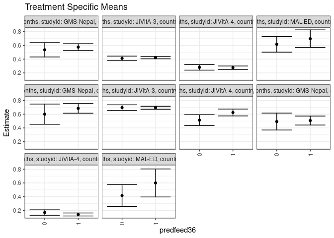

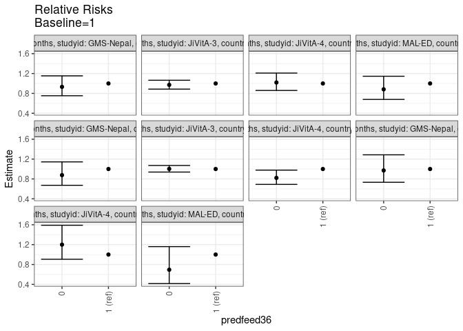

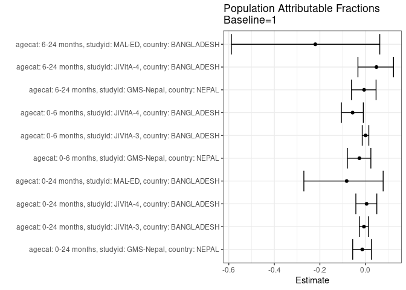

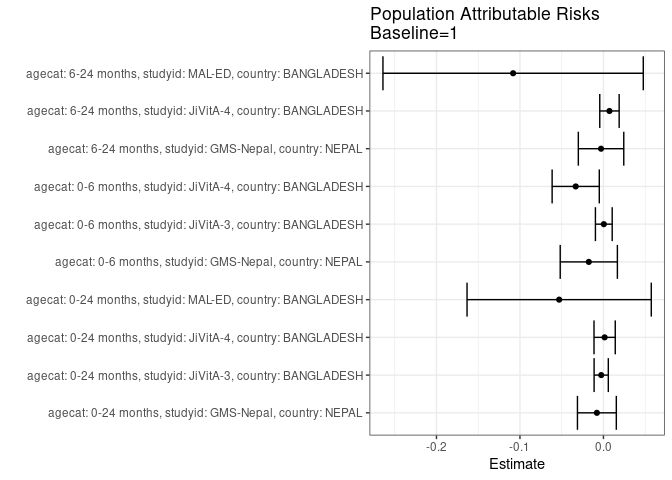

## Results Table

### Parameter: TSM

| agecat | studyid | country | intervention_level | baseline_level | estimate | ci_lower | ci_upper |
| --- | --- | --- | --- | --- | --- | --- | --- |
| 0-24 months | GMS-Nepal | NEPAL | 1 | NA | 0.5749441 | 0.5250126 | 0.6248755 |
| 0-24 months | GMS-Nepal | NEPAL | 0 | NA | 0.5357143 | 0.4313777 | 0.6400508 |
| 0-24 months | JiVitA-3 | BANGLADESH | 1 | NA | 0.4226662 | 0.4047345 | 0.4405979 |
| 0-24 months | JiVitA-3 | BANGLADESH | 0 | NA | 0.4107143 | 0.3773198 | 0.4441088 |
| 0-24 months | JiVitA-4 | BANGLADESH | 1 | NA | 0.2750191 | 0.2498837 | 0.3001545 |
| 0-24 months | JiVitA-4 | BANGLADESH | 0 | NA | 0.2803347 | 0.2399418 | 0.3207276 |
| 0-24 months | MAL-ED | BANGLADESH | 1 | NA | 0.6976744 | 0.5693135 | 0.8260353 |
| 0-24 months | MAL-ED | BANGLADESH | 0 | NA | 0.6153846 | 0.5015292 | 0.7292400 |
| 0-6 months | GMS-Nepal | NEPAL | 1 | NA | 0.6842105 | 0.6140569 | 0.7543642 |
| 0-6 months | GMS-Nepal | NEPAL | 0 | NA | 0.6000000 | 0.4531242 | 0.7468758 |
| 0-6 months | JiVitA-3 | BANGLADESH | 1 | NA | 0.6936122 | 0.6721253 | 0.7150991 |
| 0-6 months | JiVitA-3 | BANGLADESH | 0 | NA | 0.6955645 | 0.6550585 | 0.7360705 |
| 0-6 months | JiVitA-4 | BANGLADESH | 1 | NA | 0.6243094 | 0.5743715 | 0.6742473 |
| 0-6 months | JiVitA-4 | BANGLADESH | 0 | NA | 0.5129870 | 0.4339679 | 0.5920062 |
| 6-24 months | GMS-Nepal | NEPAL | 1 | NA | 0.5072464 | 0.4420152 | 0.5724775 |
| 6-24 months | GMS-Nepal | NEPAL | 0 | NA | 0.4925373 | 0.3695646 | 0.6155100 |
| 6-24 months | JiVitA-4 | BANGLADESH | 1 | NA | 0.1414995 | 0.1197019 | 0.1632970 |
| 6-24 months | JiVitA-4 | BANGLADESH | 0 | NA | 0.1697531 | 0.1297497 | 0.2097565 |
| 6-24 months | MAL-ED | BANGLADESH | 1 | NA | 0.6000000 | 0.3962234 | 0.8037766 |
| 6-24 months | MAL-ED | BANGLADESH | 0 | NA | 0.4166667 | 0.2563280 | 0.5770053 |

### Parameter: E(Y)

| agecat | studyid | country | intervention_level | baseline_level | estimate | ci_lower | ci_upper |
| --- | --- | --- | --- | --- | --- | --- | --- |
| 0-24 months | GMS-Nepal | NEPAL | NA | NA | 0.5670841 | 0.5219813 | 0.6121868 |
| 0-24 months | JiVitA-3 | BANGLADESH | NA | NA | 0.4199840 | 0.4041851 | 0.4357828 |
| 0-24 months | JiVitA-4 | BANGLADESH | NA | NA | 0.2764410 | 0.2550939 | 0.2977881 |
| 0-24 months | MAL-ED | BANGLADESH | NA | NA | 0.6446281 | 0.5577732 | 0.7314830 |
| 0-6 months | GMS-Nepal | NEPAL | NA | NA | 0.6666667 | 0.6030996 | 0.7302337 |
| 0-6 months | JiVitA-3 | BANGLADESH | NA | NA | 0.6940397 | 0.6750581 | 0.7130214 |
| 0-6 months | JiVitA-4 | BANGLADESH | NA | NA | 0.5910853 | 0.5486247 | 0.6335459 |
| 6-24 months | GMS-Nepal | NEPAL | NA | NA | 0.5043732 | 0.4466684 | 0.5620780 |
| 6-24 months | JiVitA-4 | BANGLADESH | NA | NA | 0.1487018 | 0.1295178 | 0.1678858 |
| 6-24 months | MAL-ED | BANGLADESH | NA | NA | 0.4918033 | 0.3610932 | 0.6225134 |

### Parameter: RR

| agecat | studyid | country | intervention_level | baseline_level | estimate | ci_lower | ci_upper |
| --- | --- | --- | --- | --- | --- | --- | --- |
| 0-24 months | GMS-Nepal | NEPAL | 1 | 1 | 1.0000000 | 1.0000000 | 1.0000000 |
| 0-24 months | GMS-Nepal | NEPAL | 0 | 1 | 0.9317676 | 0.7528165 | 1.1532571 |
| 0-24 months | JiVitA-3 | BANGLADESH | 1 | 1 | 1.0000000 | 1.0000000 | 1.0000000 |
| 0-24 months | JiVitA-3 | BANGLADESH | 0 | 1 | 0.9717226 | 0.8865689 | 1.0650550 |
| 0-24 months | JiVitA-4 | BANGLADESH | 1 | 1 | 1.0000000 | 1.0000000 | 1.0000000 |
| 0-24 months | JiVitA-4 | BANGLADESH | 0 | 1 | 1.0193282 | 0.8594247 | 1.2089832 |
| 0-24 months | MAL-ED | BANGLADESH | 1 | 1 | 1.0000000 | 1.0000000 | 1.0000000 |
| 0-24 months | MAL-ED | BANGLADESH | 0 | 1 | 0.8820513 | 0.6792104 | 1.1454690 |
| 0-6 months | GMS-Nepal | NEPAL | 1 | 1 | 1.0000000 | 1.0000000 | 1.0000000 |
| 0-6 months | GMS-Nepal | NEPAL | 0 | 1 | 0.8769231 | 0.6725124 | 1.1434646 |
| 0-6 months | JiVitA-3 | BANGLADESH | 1 | 1 | 1.0000000 | 1.0000000 | 1.0000000 |
| 0-6 months | JiVitA-3 | BANGLADESH | 0 | 1 | 1.0028147 | 0.9388018 | 1.0711924 |
| 0-6 months | JiVitA-4 | BANGLADESH | 1 | 1 | 1.0000000 | 1.0000000 | 1.0000000 |
| 0-6 months | JiVitA-4 | BANGLADESH | 0 | 1 | 0.8216872 | 0.6907597 | 0.9774307 |
| 6-24 months | GMS-Nepal | NEPAL | 1 | 1 | 1.0000000 | 1.0000000 | 1.0000000 |
| 6-24 months | GMS-Nepal | NEPAL | 0 | 1 | 0.9710021 | 0.7332506 | 1.2858431 |
| 6-24 months | JiVitA-4 | BANGLADESH | 1 | 1 | 1.0000000 | 1.0000000 | 1.0000000 |
| 6-24 months | JiVitA-4 | BANGLADESH | 0 | 1 | 1.1996729 | 0.9052540 | 1.5898468 |
| 6-24 months | MAL-ED | BANGLADESH | 1 | 1 | 1.0000000 | 1.0000000 | 1.0000000 |
| 6-24 months | MAL-ED | BANGLADESH | 0 | 1 | 0.6944444 | 0.4157783 | 1.1598803 |

### Parameter: PAR

| agecat | studyid | country | intervention_level | baseline_level | estimate | ci_lower | ci_upper |
| --- | --- | --- | --- | --- | --- | --- | --- |
| 0-24 months | GMS-Nepal | NEPAL | 1 | NA | -0.0078600 | -0.0311387 | 0.0154187 |
| 0-24 months | JiVitA-3 | BANGLADESH | 1 | NA | -0.0026822 | -0.0111909 | 0.0058264 |
| 0-24 months | JiVitA-4 | BANGLADESH | 1 | NA | 0.0014219 | -0.0113028 | 0.0141465 |
| 0-24 months | MAL-ED | BANGLADESH | 1 | NA | -0.0530463 | -0.1633844 | 0.0572918 |
| 0-6 months | GMS-Nepal | NEPAL | 1 | NA | -0.0175439 | -0.0517806 | 0.0166929 |
| 0-6 months | JiVitA-3 | BANGLADESH | 1 | NA | 0.0004275 | -0.0096135 | 0.0104685 |
| 0-6 months | JiVitA-4 | BANGLADESH | 1 | NA | -0.0332241 | -0.0614668 | -0.0049814 |
| 6-24 months | GMS-Nepal | NEPAL | 1 | NA | -0.0028732 | -0.0300857 | 0.0243393 |
| 6-24 months | JiVitA-4 | BANGLADESH | 1 | NA | 0.0072023 | -0.0044120 | 0.0188167 |
| 6-24 months | MAL-ED | BANGLADESH | 1 | NA | -0.1081967 | -0.2641060 | 0.0477125 |

### Parameter: PAF

| agecat | studyid | country | intervention_level | baseline_level | estimate | ci_lower | ci_upper |
| --- | --- | --- | --- | --- | --- | --- | --- |
| 0-24 months | GMS-Nepal | NEPAL | 1 | NA | -0.0138604 | -0.0558133 | 0.0264255 |
| 0-24 months | JiVitA-3 | BANGLADESH | 1 | NA | -0.0063865 | -0.0268532 | 0.0136722 |
| 0-24 months | JiVitA-4 | BANGLADESH | 1 | NA | 0.0051435 | -0.0419810 | 0.0501367 |
| 0-24 months | MAL-ED | BANGLADESH | 1 | NA | -0.0822898 | -0.2703360 | 0.0779201 |
| 0-6 months | GMS-Nepal | NEPAL | 1 | NA | -0.0263158 | -0.0792180 | 0.0239932 |
| 0-6 months | JiVitA-3 | BANGLADESH | 1 | NA | 0.0006160 | -0.0139567 | 0.0149793 |
| 0-6 months | JiVitA-4 | BANGLADESH | 1 | NA | -0.0562087 | -0.1054523 | -0.0091586 |
| 6-24 months | GMS-Nepal | NEPAL | 1 | NA | -0.0056966 | -0.0610868 | 0.0468022 |
| 6-24 months | JiVitA-4 | BANGLADESH | 1 | NA | 0.0484348 | -0.0328132 | 0.1232913 |
| 6-24 months | MAL-ED | BANGLADESH | 1 | NA | -0.2200000 | -0.5887217 | 0.0631462 |